# Discrete Time Cyber Example

## Motivation

In attack and detection games, Nash equilibria strategies are typically mixed strategies. For obvious reasons, this holds for static games but less obviously also holds for dynamic games. This is especially true for the vast majority (all?) of cyber attack games. In the dynamic version of these games, the order of events are

- Attacker moves and generates a signal
- sensors receive the signal and stochastically sets a state
- Defender observes the noisy sensor
- the defender makes a decision

A simple example (but also widely used) would be a game where the attacker has two strategies, {attack, don't attack], the sensor has two states, [compromised, not compromised], and the transition of states depend on the action of the attacker, the defender has two actions [defend, don't defend].

Such a strategic scenario is not trivial due to the noise in the sensor. That is, there is a positive probability that even if the attacker chooses to attack, the sensor's state will be "not compromised." Nevertheless, mixed strategies are easily solved for using backward induction and value iteration (when the game is one of perfect information.)

Note that in such a model, an attacker is always present in the network but is sometimes "lying dormant." That is, he may choose not to attack but always remains in the network.

In real world detection scenarios, the attacker is either in the network or not. The probability of an attacker actually being in the network is **not** an element of the strategic scenario but is determined exogenously (there are practical motivations for this). However, if the random variable determines an attacker is in the network, a game similar in nature to that described above plays out. In other words, once the attacker is in a network, the (possibly not fixed) sequence of events are attacker moves, signal generated, sensors change state, defender makes a decision...repeat as necessary.  
If the random variable determines that the attacker is not present in the network, then the defender still receives a signal from noisy sensors and must determine whether or not the attacker is present.

More specifically, the defender must estimate the state of a binary variable that is determined *exogenously* based on the reading of a (set of) sensors. Note that this is different than the game described in the bulleted list above as in that scenario, the defender's goal is to estimate the value of a binary variable *set* by the attacker.

While this difference is subtle, it (may) have several important implications. The main implication (might be) is:

- Contrary to most attack/detection models, there exits *pure-strategy* Nash equilibria in cyber attack scenarios.
- It means we can develop more accurate models of attacker behavior instead of relying on stochastic strategies (less important).
- Depending on the formalization, attack and detection games *do* yield pure strategy Nash equilibria. This is important because it means that agents do not need to 'randomize' to confuse their opponents. Instead, agents will confuse their opponents by attempting to make their activity "look similar" to normal, noisy behavior.

The central model of a dynamic attack scenario is Basar and Alcapan (2006) “An intrusion detection game with limited observations” where the authors develop a simple model and solve for a mixed strategy Nash equilibrium. This notebook will slightly extend this model to explore the new insights that arise from a slightly more complex and realistic model.

## Outline

- A sensor with states $1,2,3,4,5...N$
- Without an attacker, sensors follow a symmetric drunkards walk
- Defender must choose a threshold to signal an attack
- At each timestep, an attacker chooses "attack" or "no attack". If the attacker attacks, the sensor deterministically increases by 1 and continues following a drunkards random walk. If the attacker does not attack, the sensor evolves according to the probability transition matrix.
- The attacker must choose whether or not to attack in each time period

## Setup

- The model is a game between two players --- an attacker and a defender.
- There is a sensor with integer states $S = \{1,2,3,...N\}$
- The game is dynamic and time is discrete and finite (for now), $\mathcal{T} = \{1,2,3...T\}$, $T \geq N$
- The sensor is modeled as a discrete time Markov chain with probability transition matrix $\mathbb{P}$
- $\mathbb{P}$ is $N \times N$, furthermore for simplicity, assume $N$ is an absorbing state.
- Notationally, $[X]_{i,j}$ refers to the element in row $i$ and column $j$ of matrix $X$
- Furthermore for each row $i$ of $\mathbb{P}$, $p_{ik}=0$ for $k<i-1$ and $k>i+1$. Intuitively, in one timestep the sensor can only increase by one, decrease by one or not change.

The sequence of events is as follows

- At the start of the game, the defender chooses a threshold strategy $d\in \mathcal{D} = \{1,2,...N\}$.
- The sensor depends on the choice of $d$ such that the $\mathbb{P}$ remains the same except that all states $\geq d$ become absorbing states.
- Then exogenous parameter $\pi_A$ determines whether an attacker is present in the network.
  - If the attacker is not present in the network, then the sensor evolves according to $\mathbb{P}$. The defender's reward is the number of time periods before the threshold is reached, or the game ends, $\min(T, H(d))$, where $H(d)$ is the time that the sensor first hits $d$.
  - If the attacker is present in the network, at every time step, he must choose to not attack or attack, which are coded as binary variables where attacking corresponds to $1$: $\mathcal{A} =\{0,1\}$
  - The attacker does *not* observe the state of the sensor.
  - The attacker's action at time $t$ is a mapping $ a_t: [0,1]^{t-1}\rightarrow [0,1]$
  - The attacker's strategy is then a set of functions $\{a_t\}_{t=1}^T$
  - The attacker's reward at time $t$ is defined as: \begin{align} R_t(0) = 0 \\ R_t(1) = 1 \text{ if } S_t<d \\ R_t(1) = 0 \text{ if } S_t =d \end{align}
  - Intuitively, the attacker receives a reward if he chooses to attack while the sensor has not yet reached his threshold
  - The probability transition matrix also depends on $a_t$ in the following way.
    - If $a_t(\cdot)=0, \text{ then } \mathbb{P}(a_t(\cdot), d)=\mathbb{P}$ (No change)
    - If $a_t(\cdot) =1$:
      - $\mathbb{P}_{i,0}(a_t(\cdot), d) = 0 \text{ for } \; i=1...d$
      - $\mathbb{P}_{i,j}(a_t(\cdot), d) =\mathbb{P}_{i, j-1} \text{ for } \; j=2...d, i=1...d-1$
      - $\mathbb{P}_{d-1,d}(a_t(\cdot), d) =\mathbb{P}_{d-1, d} + \mathbb{P}_{d-1, d-1}$
      - $\mathbb{P}_{d,d}(a_t(\cdot), d) = 1$
    - Intuitively, when the attacker chooses to attack, he deterministically increases the state of the sensor by $1$. For example, suppose the probability transition matrix governing the state of the sensor without an attacker is given by:

$\mathbb{P}= \begin{bmatrix} q&1-q& 0 &0&0 \\ p_1 &p_2&p_3& 0&0 \\ 0& p_1&p_2&p_3&0\\ 0&0& p_1&p_3&p_3\\ 0& 0&0&0&1 \end{bmatrix}$.

If the attacker chooses to attack at time $t$, the transition matrix that now governs the system at time $t$ is given by:

$\mathbb{P_t}(a_t=1)= \begin{bmatrix} 0&q&1-q& 0 &0 \\ 0&p_1 &p_2&p_3& 0 \\ 0&0& p_1&p_2&p_3\\ 0&0& 0&p_1&p_2+p_3&\\ 0& 0&0&0&1 \end{bmatrix}$.

- Other assumptions
  - Sensor follows a bounded symmetric drunkards walk: The probability of increasing in state, decreasing in state or remaining in the current state is the same for all states. Mathematically this means that $\mathbb{P}_{ij} = \mathbb{P}_{i+1, j}$ for all non absorbing or edge states. More concretely, if we let $p_1, p_2, p_3$ be a proper probability distribution then an example the matrix $\mathbb{P}$ is of the form:

$\mathbb{P}= \begin{bmatrix} q&1-q& 0 &0&0&0&...&0 \\ p_1 &p_2&p_3& 0&0&0&...&0 \\ 0& p_1&p_2&p_3&0&0&...&0\\ 0&0& p_1&p_2&p_3&0&...&0\\ \vdots&\vdots&\vdots&\vdots&\vdots&\vdots&\vdots&\vdots\\ \end{bmatrix} = \begin{bmatrix} q&1-q& 0 &0&0&0&...&0 \\ p_1 &(1-2p_1)&p_1& 0&0&0&...&0 \\ 0& p_1&(1-2p_1)&p_1&0&0&...&0\\ 0&0& p_1&(1-2p_1)&p_1&0&...&0\\ \vdots&\vdots&\vdots&\vdots&\vdots&\vdots&\vdots&\vdots\\ \end{bmatrix}$

Intuitively, the defender earns utility for each time step the attacker is not in the network (this is equivalent to saying that the defender earns utility for each period there is *not* a false alarm). The defender incurs a negative utility for each period the defender *is* present in the network. Note that (for now) this is independent of the attacker's actions. Also note that the only way the attacker's actions impact the defender's decision is through the expected hitting time when an attacker is present.

The attacker's (expected) utility is given by: \begin{align} U_A (d, \{a_t\}_{t=1}^T) &= \sum_{t=1}^T \sum_{k=1}^ta_k(\cdot)P\bigg(H(d, \{a_j\}_{j=1}^T)=t+1\bigg) \\ &=\sum_{t=1}^T\bigg[ P\bigg(H(d, \{a_j\}_{j=1}^T)=t+1\bigg) \sum_{k=1}^ta_k(\cdot)\bigg] \end{align}

Intuitively the attacker's expected utility from a strategy is the expected number of times he will attack before the threshold is reached.

In the usual sense, a pure strategy Nash equilibrium of this game are strategies $\big(d^*$, $\{a^*_t\}_{t=1}^N\big)$ such that:

\begin{align} U_D(d^*, \{a^*_t(\cdot)\}_{t=1}^N)&\geq U_D(d^{\prime}, \{a^*_t(\cdot)\}_{t=1}^N) \; \; \forall \; \;d^{\prime} \\ &\text{ And } \\ U_A(d^*, \{a^*_t(\cdot)\}_{t=1}^N)&\geq U_A(d^*, \{a^{\prime}_t(\cdot)\}_{t=1}^N) \; \;\forall \; \; \{a^{\prime}_t\} \\ \end{align}

## More Details

### The Defender

Given a threshold $d$, we can compute the probability of hitting times for the defender when an attacker is not present. By construction, if the system reaches the defender's threshold it remains in that state for the remainder of the game. In other words, $d$ is an absorbing state. Given a strategy $d$, the probability transition matrix that now governs the system, $\mathbb{P}_d$, is given by:

\begin{align} [\mathbb{P}(d)]_{i,j} = [\mathbb{P}]_{i,j} \; \; \text{if} \;\; i \neq d \\ [\mathbb{P}(d)]_{d,d} = 1 \\ [\mathbb{P}(d)]_{d,j\neq i } = 0 \end{align}

There probability of being in state $d$ at time $t$, given that we start at state $0$ and no attacker is present in the network is given by \begin{equation} P(S(t)=d) = [\mathbb{P}(d)]^t_{1,d} \end{equation}

However, since $d$ is an absorbing state,the probability of the hitting time $P(H(d)=t)$, is given by:

\begin{equation} P(H(d)=t)=P(H(d)\leq t)- P(H(d) < t)=P(S(t)=d)-P(S(t-1)=d) \end{equation}.

Therefore, when the attacker is not present in the network, the defender's expected utility is given by: \begin{equation} E\big[H(d)\big]= \sum_{t=2}^{T-1}t[\mathbb{P}(d)^t -\mathbb{P}(d)^{t-1} ]_{1,d} + T(1-[\mathbb{P}(d)^{T-1}]_{1,d}) + [\mathbb{P}]_{1,d} \end{equation} The second and third term represent the contribution to expected utility when the hitting time is equal to $T$ and equal to $1$, respectively.

When the attacker is in the network, the probability transition matrix that governs the sensor depends on the action of the attacker at each time-step. Therefore, it is not possible to compute the probability of the hit time as an entry of a matrix raised to a power. Instead, it must be computed as the product of time heterogeneous matrices. In other words, given a defender's strategy, $d$ and an attacker's strategy $\{a_t(\cdot)\}_{t=1}^N$, the probability of hit times (for times $\geq 2$) is given by:

\begin{equation} P\bigg(H(d, \{a_j\}_{j=1}^T)=t\bigg) = \bigg[\prod_{h=1}^t\mathbb{P}(a_h(\cdot), d) - \prod_{h=1}^{t-1}\mathbb{P}(a_h(\cdot), d)\bigg]_{1,d} \end{equation}

Therefore, the expected utility of the defender when the attacker is present in the network is given by: \begin{equation} E\big[H(d, \{a_t\}_{t=1}^T)\big] = \sum_{t=2}^{T-1}t\bigg[\prod_{h=1}^t\mathbb{P}(a_h(\cdot), d) - \prod_{h=2}^{t-1}\mathbb{P}(a_h(\cdot), d)\bigg]_{1,d} + [\mathbb{P}(a_1(\cdot), d)]_{1,d} + T\big(1-\big[\prod_{h=1}^{T-1}\mathbb{P}(a_h(\cdot), d)\big]_{1,d}\big) \end{equation}

### The Attacker

Recall that the attacker's expected utility is the expected number of times the attacker chooses to attack before the sensor reaches state $d$. In deriving the defender's expected utility, we have also defined the probability of the hitting times. Using the same formula for expected hitting time, we can define the expected utility of the attacker as \begin{align} U_A (d, \{a_t\}_{t=1}^T) &=\sum_{t=1}^T\bigg[ P\bigg(H(d, \{a_j\}_{j=1}^T)=t+1\bigg) \sum_{k=1}^ta_k(\cdot)\bigg]\\ & = \sum_{t=2}^{T}\bigg(\big[\sum_{\tau=1}^{t-1}a_\tau(\cdot)\big]\bigg[\prod_{h=1}^t\mathbb{P}(a_h(\cdot), d) - \prod_{h=2}^{t-1}\mathbb{P}(a_h(\cdot), d)\bigg]_{1,d} + \big(1-\prod_{h=1}^{T}\mathbb{P}(a_h(\cdot), d)\big)\bigg)\sum_{\tau=1}^{T}a_\tau \end{align}

### A note on the novel element

The main source of novelty in this formulation is the addition of the defender having to make a decision, even when no attacker is present. In the current literature, the games assume that the attacker and defender are playing a game. Then, each agent chooses an equilibrium strategy "knowing" that they are playing against an opponent.

In this model (and the real world) this is not the case. Often times, cyber networks have not been compromised by an attacker and therefore the defender is not actively playing a game against an attacker. Instead, he is trying to "guess" whether or not a game is actually being played. Since this is the only difference in the formulation of the game from that of the current literature, I believe it is this facet that drives the somewhat novel results.

### The code

```python
from adsy.display import extended_styles
from matplotlib import rc
from itertools import product
from matplotlib import pyplot as plt
import numpy as np
import copy
rc('text', usetex=True)
%matplotlib inline
extended_styles()
```

Toggle Input

```python
P = np.zeros((21,21))
P[0,0]=.25
P[0,1] =.75
for i in range(1,10):
    P[i, i-1]=.25
    P[i, i+1] =.25
    P[i,i]=.5
P[i+1,i]=0
P[i+1,i+1]=1
class DiscreteMarkovAttackGame(object):
    """
    The game's initial state is at T_0.
    Then the game is played for 10 time steps.

    N is the number of states, not ioncluding 0, so we need to add 0?

    The Nth row of P corresponds to state N-1 and has index N

    The integer N is one less than the dimension of P because P includes state 0

    No false alarm is the reward a defender receives for not sounding an alarm when the attacker is not positive (true negatives)
    """

    def __init__(self, P, N=10, T=10, pi_A=.05, no_false_alarm = 1):
        self.P = P
        self.N = N
        self.T =T
        self.pi_A = pi_A
        self.p1 = P[1,0]
        self.q2 =  P[0,1] # 1-q
        #self.defenders_first = np.arange(0,T+1)**2/float(2*self.p1) + (
        #    2*self.p1-self.q2)/(2*self.p1*self.q2)*np.arange(0,T+1)
        # The analytical Solution only works for infinite horizon
        self.defenders_first = [self._get_defenders_first(i) for i in range(1,N+1)] # Generates numbers 1...N
        self.attackP = self.get_attackp()
        self.attacker_strategies = [list(x) for x in set(product(set((0, 1)), repeat = self.T))]
        self.no_false_alarm=no_false_alarm


    def _get_defenders_first(self, d):
        """
        CDF

        The ith element of the returned list is the probability
        of reaching "state" at or before timestep i
        """
        steps_ahead=self.T # The maximum number of time steps
        state=d+1 # Add one because state will be used as an index for ConditionalP
        P = self.P
        conditionalP = np.copy(P)
        conditionalP = conditionalP[0:state, 0:state]
        conditionalP[-1, :]=0
        conditionalP[-1, -1]=1
        P0 = np.zeros((conditionalP.shape))
        conditionalP = np.mat(conditionalP)
        x0 = np.mat(np.zeros((1, state)))
        #print x0.shape, P.shape, conditionalP.shape
        x0[0,0]=1
        probs = [0]
        for i in range(1,steps_ahead+1): # Generates numbers 1...T
            probs.append(np.dot(x0, conditionalP**i)[0,-1])
        pdf = np.diff(probs)
        pdf[-1] = 1-np.sum(pdf[:-1])
        #print pdf
        return np.sum(np.arange(1, len(pdf)+1)*pdf)

    def get_attackp(self):
        attackP = np.copy(self.P)
        attackP[0][0] = 0
        attackP[0][1] = self.P[0][0]
        attackP[0][2] = self.P[0][1]
        for j in range(self.P.shape[0]-1):
            attackP[j, :] = self.P[j+1, :]
        return attackP




    def get_matrix_sequence(self, attacker_strategy):
        """
        Returns a sequence of time dependent probability transition matricies given the attacker's strategy
        """
        p_seq = []
        for action in attacker_strategy:
            if action ==0:
                p_seq.append(copy.deepcopy(self.P))
            elif action ==1:
                p_seq.append(copy.deepcopy(self.attackP))
            else:
                raise
        return p_seq

    def defenders_utility_given_attacker(self, d, attacker_strategy):
        """
        Computes Defender's utility for choices of d and a
        """
        noattackeru = (1-self.pi_A)*self.defenders_first[d-1] # Index -1
        matrixseq = copy.deepcopy(self.get_matrix_sequence(attacker_strategy))
        newseq = []
        for j in range(len(matrixseq)):
            m = copy.deepcopy(matrixseq[j])
            #m is N=1 X N+1 with max index N
            # d goes from 1...N
            if d <self.N:
                m[d,d]=1
                m[d, d-1]=0
                m[d, d+1]=0
            if attacker_strategy[j]==1:
                if d==1:
                    m[0][0] = 0
                    m[0][1] =1
                elif d< self.N-1:
                    m[d-1, d-1]= self.p1
                    m[d-1, d-2]=0
                    m[d-1, d] = self.p1 + (1-2*self.p1)
                    m[d-1, d+1] = 0
                    m[d, d+2]= 0
                elif d == self.N-1:
                    m[d-1, d-1]= self.p1
                    m[d-1, d-2]=0
                    m[d-1, d] = self.p1 + (1-2*self.p1)
                    m[d-1, d+1] = 0
                elif d == self.N:
                    m[d-1, d-1]= self.p1
                    m[d-1, d-2]=0
                    m[d-1, d] = self.p1 + (1-2*self.p1)
            newseq.append(m)
        hitting_cdfs = []
        start = np.zeros((1,self.P.shape[0]))
        start[0][0]=1
        pdf= [0]
        for j in range(0, self.T):
            start = np.dot(start, newseq[j])
            pdf.append(start[0][d] - sum(pdf))
        pdflast =copy.copy(pdf[-1])
        pdf[-1] = 1-sum(pdf[:-1])
        with_attacker_eu = np.sum(np.arange(0, len(pdf))*np.asarray(pdf)) * self.pi_A
        defenders_final_utility = self.no_false_alarm * noattackeru - with_attacker_eu
        ### Now get attacker's utility
        ### Need to adjust PDF for attacker because even if the game ends at T, he might still receive
        ### a reward at T.
        au = np.sum(np.sum(attacker_strategy[:x-1]) *np.sum(pdf[x:]) for x in range(2, len(attacker_strategy)+1)) + \
            attacker_strategy[-1] * (np.sum(pdf[:-1])+ pdflast)

        #+ \
            #attacker_strategy[-1]*np.sum(pdf)
        # for x =2,3,4,5,6,7,8,9,10 what is the attacker's utility given the alarm sounds
        # in period 2,3,4,5,6,7,8,9,10.  It is the sum of a1 +a2...a_{p-1}
        return defenders_final_utility, au

    def defenders_best_response(self, attacker_strategy):
        eu= [- np.inf]
        d_max =[]
        for d in range(1,self.N+1):
            pot_eu = self.defenders_utility_given_attacker(d, attacker_strategy)[0]
            if pot_eu == eu[0]:
                eu.append(pot_eu)
                d_max.append(d)
            if pot_eu > eu[0]:
                eu = [pot_eu]
                d_max = [d]
        return d_max, eu


    def attackers_best_response(self, d):
        eu= [- np.inf]
        astrat= []
        for a in self.attacker_strategies:
            pot_eu = copy.deepcopy(self.defenders_utility_given_attacker(d, a)[1])
            if pot_eu == eu[0]:
                eu.append(pot_eu)
                astrat.append(a)
            if pot_eu > max(eu):
                eu = [pot_eu]
                astrat = [a]

        return astrat, eu

    def brute_force_solve(self):
        eqs= []
        attackers_response= {} # Values are lists!
        for d in np.arange(2,self.N+1):
            attackers_response[d] = self.attackers_best_response(d)[0] # Dictionary from defender strategy to attacker BR list
        defenders_response = {}
        for key, val in attackers_response.iteritems():
                for v in val:
                    defenders_response[str(v)] = self.defenders_best_response(v)[0] # Maps attackers actions to defender BR
        #return attackers_response, defenders_response
        for key, val in attackers_response.iteritems():
            for v in val:
                for dr in defenders_response[str(v)]:
                    if dr == key:
                        eqs.append((defenders_response[str(v)], v))
        if len(eqs)>1:
            print 'Multiple Equilibria'
        return eqs
```

### Results

- The parameters used were $T=10$, $N=10$, $q=.25$, $p_1=.25$ Other parameters were varied in the experiments
- There does exist a pure strategy Nash equilibrium
  - This implies that in attack and detection games with a noisy sensor, agents do *not* need to randomize to outsmart their opponents. Instead, the attacker will pick a pure strategy that allows him to "hide" in the background noise. In other words, instead of using randomization to disguise his strategy, the attacker tries to use normal background noise to hide his malicious behavior.
  - Similaraly, this implies that defenders also do not need to randomize their strategy to confuse the attacker. This is an important result because real world defenders do not randomize their strategy but typically set a fixed threshold.
- Another result that is novel and has only been tangentially explored before is that increasing the probability of an attempted attack makes the defender more sensitive (see experiment 1).
- Although this result does yield a pure strategy Nash equilibrium, the results are still consistent with the situational foundation. For example decreasing the cost of a false alarm makes the reduces the defender's threshold, $d$ (see experiment 2). In that sense, it retains all of the accepted intuition but adds a little snippet that shows attacker do not need to randomize their strategy in order to outsmart their opponent (and vice versa).
- The attacker exhibits "patience". In other words, the attacker does not choose to attack every period. This is important because current cyber attack detection assumes that once attacker's are able to traverse a network, they do so as fast as possible. This simple model demonstrates that attackers will sometimes choose not to send messages in the hopes that by being patient, the sensor will move away from the defender's threshold.

### Experiment 1, varying intrusion probability

```python
defenderstrat = []
for ap in np.arange(.01, .5, .1):
    Game= DiscreteMarkovAttackGame(P, pi_A=ap, N=10, T=10)
    defenderstrat.append(Game.brute_force_solve()[0][0])
```

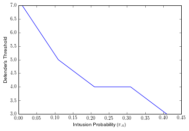

```python
plt.plot(np.arange(.01, .5,.1), defenderstrat)
plt.ylabel('Defender\'s Threshold')
plt.xlabel('Intrusion Probability ($\pi_A$)')
```

### Experiment 2 - "Raising the cost of a false alarm"

```python
defenderstrat2 = []
for fa in np.arange(1,5 ,1):
    Game= DiscreteMarkovAttackGame(P, pi_A=.25, N=10, T=10, no_false_alarm=fa)
    defenderstrat2.append(Game.brute_force_solve()[0][0])
```

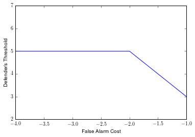

```python
defenderstrat2[0]=[3]
plt.plot(-np.arange(1, 5, 1), defenderstrat2)
plt.ylim(2,7)
plt.ylabel('Defender\'s Threshold')
plt.xlabel('False Alarm Cost')
```

### Discussion and Extensions

Here, I have developed a game where the defender must estimate whether or not an attacker is present in the network by observing a noisy sensor. This is a very stylized game where the defender simply chooses an integer threshold and the attacker simply chooses "attack" and "don't attack". We have shown that a pure strategy Nash equilibrium exists in such a framework. This implies that instead of masking an attack by randomizing, the attacker masks his attack by trying to appear like noise, a novel result.

From here, there are two possible path's (and I have a feeling I will be taking both):

1) I can continue to investigate this stylized model. Some questions that arise are:

- Is the defender's strategy indeed a threshold strategy? In this example, it was restricted to a threshold strategy because that is how current attack defenders operate. However, it might be the case that by not choosing a threshold strategy, the defender can increase his expected utility.
- What are the closed form solutions for the Nash equilibrium and what general results do we see? This is more of an open ended question that is just further development of this work.

2) De-stylize the simple model. In the real world, attackers do not simply attack one target but traverse a network and receive rewards as they encounter valuable targets. Furthermore, the defender does not only observe one sensor but observes multiple sensors and must choose a decision rule for a reading of all sensors. Incorporating these elements raise many questions:

- First and foremost, how convenient is it to formulate and solve the more complex scenario? Is it possible to formulate the more realistic version of the model using well-established tools?
- Do the results of a more complex scenario remain consistent with the traditional formulation? If not, what are the differences? If so, what is the driving force that applies to **all** formulations.

My initial plan was to take path 2). However, I think that the approach is different now. In other words, before I was focusing on simply jumping into a more complex scenario and showing how a smart detector can do better than a dumb(er) one. I think (hope) that by starting from this simple version of a model and building up, there will be much more to uncover. In other words, at each step I will be comparing the results of a more complex scenario with the simple baseline model (the one that I presented here, that is indeed different from the current literature). So, a general progression of the work would be as follows:

1) Present the model here that will be used as a baseline. Also note how this model has an element that previous models do not

2) Begin extending the model piece by piece (adding a network component, adding multiple sensors, etc). In the process, explore how well the tools available to me can represent the scenario.

2b) As each extension is built, compare the results with the results of the baseline case

3) **ONLY IF CURRENT TOOLS PROVE TO BE INADEQUATE** introduce a new way to model strategic scenarios and then employ that method to the problem

4) Show how a smart detector performs better than a dumber one (in a game theoretic framework, not with simulated data). More specifically, show the changes in defender's utility when he uses different forms of detectors.

4b) (Possibly) show how the defender's ability to exploit knowledge of the attacker's strategy is not obvious in the simple formulations of the game. Or, if it is possible to exploit knowledge of an attacker's strategy to improve detection in the simple stylized examples, show how there is a parallel when considering real-world network intrusion scenarios.

### Justin's Scratch notes

It can be shown (I have sketched out a proof), that the first term in the defenders utility function is quadratic in $d$. That is, $\pi_A(E\big[H(d)\big]) = \pi_A(ad^2 +bd)$ for some constants $a$ and $b$ that are determined by the probabilities in $\mathbb{P}$ More specifically, $a= \frac{1}{2p_1}$ and $b= \frac{2p_1 -q_2}{2p_1q_2}$, where $p_1$ is the probability of stepping up from any state other than $0$ and $q_2$ is the probability of moving away from state 0.

```python
Game= DiscreteMarkovAttackGame(P, pi_A=.21, N=10, T=10, no_false_alarm=1)
```

```python
sol=Game.brute_force_solve()
```

```python
Game.attackers_best_response(3)
```

```
([[1, 1, 0, 0, 0, 0, 1, 1, 1, 1]], [8.6552085876464844])
```

```python
Game.defenders_utility_given_attacker(6, [1,1,0,0,0,0,0,0,0,0])
```

```
(-6.8471768188476556, 16.627952575683594)
```

```python
Game.defenders_best_response([1,1,0,0,0,0,1,1,1,1])
```

```
([5], [6.0237060165405278])
```

```python
Game.defenders_utility_given_attacker(1, [1,1,0,0,0,0,0,0,0,0])
```

```
(0.49879264831542969, -1.3285064697265625)
```